# Practical Machine Learning project

Justas Godliauskas

20 Dec 2014

**Short summary**  
Some cleaning of the data is performed at first. Also number of features is reduced to 14 from 158, by removing ones with high correlation among each other and ones that have very small correlation with predicted variable. Also remove features that have many NA values.

Simple cross-validation is used. Avoid k-folds because of long computation time. Simply split train data to training and testing sets.

Evaluate 3 models: boosting, random forest and simple trees on training set. Select one that performes best on testing set.

Random forest turns out to be the best, giving ~96% accuracy on testing set. And as found out later 20/20 score on the submission.

```r
library(RCurl)
library(caret)
library(randomForest)

# get training and test data
myCsv1 <- getURL("https://d396qusza40orc.cloudfront.net/predmachlearn/pml-training.csv")
dt1 <- read.csv(textConnection(myCsv1))
TRAIN <- dt1[, !colnames(dt1) %in% "X"]

myCsv2 <- getURL("https://d396qusza40orc.cloudfront.net/predmachlearn/pml-testing.csv")
dt2 <- read.csv(textConnection(myCsv2))
test <- dt2[, !colnames(dt2) %in% "X"]

# identify features in test data that have only NA
allna <- sapply(test, function(k) all(is.na(k)))
allna.names <- names(allna[allna])
```

First, check features and reduce them in order to reduce estimation time and avoid overfitting.

```r
# ignore NA variables
TRAIN <- TRAIN[, !colnames(TRAIN) %in% allna.names]
test <- test[, !colnames(test) %in% allna.names]

# now each of belt, arm, forearm, dumbbell has 13 features
# identify factors (that are characters)
classes <- sapply(TRAIN, class)
factors <- names(classes[classes == "factor"])
# there 3 factors as a features
# two of them show no relation to predictable variable, remove them
table(TRAIN[, c("user_name", "classe")])
```

```
##           classe
## user_name     A    B    C    D    E
##   adelmo   1165  776  750  515  686
##   carlitos  834  690  493  486  609
##   charles   899  745  539  642  711
##   eurico    865  592  489  582  542
##   jeremy   1177  489  652  522  562
##   pedro     640  505  499  469  497
```

```r
table(TRAIN[, c("new_window", "classe")])
```

```
##           classe
## new_window    A    B    C    D    E
##        no  5471 3718 3352 3147 3528
##        yes  109   79   70   69   79
```

```r
remove <- c("user_name", "new_window")
TRAIN <- TRAIN[, !colnames(TRAIN) %in% remove]
test <- test[, !colnames(test) %in% remove]

table(TRAIN[, c("cvtd_timestamp", "classe")])
```

```
##                   classe
## cvtd_timestamp       A   B   C   D   E
##   02/12/2011 13:32 177   0   0   0   0
##   02/12/2011 13:33 988 333   0   0   0
##   02/12/2011 13:34   0 443 750 182   0
##   02/12/2011 13:35   0   0   0 333 686
##   02/12/2011 14:56 235   0   0   0   0
##   02/12/2011 14:57 664 716   0   0   0
##   02/12/2011 14:58   0  29 539 642 154
##   02/12/2011 14:59   0   0   0   0 557
##   05/12/2011 11:23 190   0   0   0   0
##   05/12/2011 11:24 644 690 163   0   0
##   05/12/2011 11:25   0   0 330 486 609
##   05/12/2011 14:22 267   0   0   0   0
##   05/12/2011 14:23 373 505 492   0   0
##   05/12/2011 14:24   0   0   7 469 497
##   28/11/2011 14:13 833   0   0   0   0
##   28/11/2011 14:14  32 592 489 385   0
##   28/11/2011 14:15   0   0   0 197 542
##   30/11/2011 17:10 869   0   0   0   0
##   30/11/2011 17:11 308 489 643   0   0
##   30/11/2011 17:12   0   0   9 522 562
```

```r
# cvtd_timestamp looks very important, need to format it to make use of it
# Note that earlier the excercise is perfomed the better it is done
formatDate <- function(x){
    x <- substr(x, 12, 16)
    x <- strsplit(x, ":")
    x <- lapply(x, function(k){
        as.numeric(k[1]) * 60 + as.numeric(k[2])
    })
    x <- Reduce("c", x)
    x <- c(0, diff(x))
    x[abs(x) > 1] <- 0
    which.zeros <- x == 0
    temp <- cumsum(x)[which.zeros]
    temp <- -c(0, rev(diff(rev(temp))))
    x[which.zeros] <- -temp
    x <- cumsum(x)
    x
}

FixTimeStamp <- function(x){
    x[, "cvtd_timestamp"] <- as.character(x[, "cvtd_timestamp"])
    unique.stamp <- sort(unique(x[, "cvtd_timestamp"]))
    unique.stamp.short <- formatDate(unique.stamp)

    for (i in 1:length(unique.stamp)){
        x[, "cvtd_timestamp"] <- gsub(unique.stamp[i], unique.stamp.short[i],
                                      x[, "cvtd_timestamp"])
    }
    x[, "cvtd_timestamp"] <- as.integer(x[, "cvtd_timestamp"])
    x
}

TRAIN <- FixTimeStamp(TRAIN)
test <- FixTimeStamp(test)
```

Number of features may still be too big. Try to identify ones that have high correlation among each other and very low correlation with **classe** variable. Perform basic *Pearson* correlation and do not pay too much attention to assumptions.

```r
# change categorical variables to integers, in orider to perform correlations
not.numeric <- !sapply(TRAIN[1, ], is.numeric)
not.numeric <- not.numeric[not.numeric]

# only classe variable is as character now
# transform it to number
TRAIN$classe <- as.numeric(as.factor(TRAIN$classe))

# remove features that have correlations with classe < 0.1 in absolute terms
cors <- abs(cor(TRAIN)[, "classe"])
rem.features1 <- names(cors[cors < 0.1])
TRAIN <- TRAIN[, !colnames(TRAIN) %in% rem.features1]
test <- test[, !colnames(test) %in% rem.features1]

cors <- cor(TRAIN[, !colnames(TRAIN) %in% "classe"])
# features that are very correlated with each other
cors[lower.tri(cors, diag = TRUE)] <- 0
cor.features <- list()
for (col in colnames(cors)){
    row <- rownames(cors)[which(cors[, col] > 0.8)]
    if (length(row) == 0)
        next
    else
        cor.features <- c(cor.features, list(c(row, col)))
}

rem.features2 <- c()
while(length(cor.features) > 0){
    for (i in 1:length(cor.features)){
        pairs <- cor.features[[i]]
        pairs <- pairs[!pairs %in% rem.features2]
        if (length(pairs) < 2){
            cor.features[i] <- NA
            next
        }
        take <- cor.features[[i]][1]
        pairs <- pairs[!pairs %in% take]
        if (length(pairs) < 2){
            cor.features[i] <- NA
        }
        cor.features[[i]] <- pairs
        rem.features2 <- c(rem.features2, take)
    }
    cor.features <- cor.features[!sapply(cor.features, function(k)
        all(is.na(k)))]
}

TRAIN <- TRAIN[, !colnames(TRAIN) %in% rem.features2]
test <- test[, !colnames(test) %in% rem.features2]
# features to remove
rem.features <- c(rem.features1, rem.features2)
```

Done with data preparation. There are 14 features left plus predicted variable.

```r
colnames(TRAIN)
```

```
##  [1] "cvtd_timestamp"      "magnet_belt_y"       "magnet_belt_z"
##  [4] "pitch_arm"           "total_accel_arm"     "magnet_arm_x"
##  [7] "magnet_arm_z"        "accel_dumbbell_x"    "magnet_dumbbell_z"
## [10] "pitch_forearm"       "total_accel_forearm" "accel_forearm_x"
## [13] "magnet_forearm_x"    "magnet_forearm_y"    "classe"
```

Fit models now. In order to save time and keep it simple basic cross-validation is used. Training set is split to training and testing sets. Evaluation of few different models is performed on training set, and performance tested on testing set. Based on accuracy of prediction one model is selected for final prediction.

```r
# not important transformation
TRAIN$classe <- as.character(TRAIN$classe)
TRAIN$classe <- gsub("1", "A", TRAIN$classe)
TRAIN$classe <- gsub("2", "B", TRAIN$classe)
TRAIN$classe <- gsub("3", "C", TRAIN$classe)
TRAIN$classe <- gsub("4", "D", TRAIN$classe)
TRAIN$classe <- gsub("5", "E", TRAIN$classe)
TRAIN$classe <- factor(TRAIN$classe)

# create training and testing sets
set.seed(100)
f <- createDataPartition(y = TRAIN$classe, p = 0.75, list = FALSE)
training <- TRAIN[f, ]
testing <- TRAIN[-f, ]
```

Boosting method performes quite well, giving ~90% accuracy

```r
# fit boosting model
fit.bo <- train(classe ~ ., data = training, method = "gbm",
                verbose = FALSE)
p.bo <- predict(fit.bo, testing)
res.bo <- p.bo == testing$classe
res.bo <- sum(res.bo)/(length(res.bo)) * 100 # precentage of correct predictions
res.bo
```

```
## [1] 90.82382
```

[output not shown]

Random forest work extremely well. ntree = 10 is chosen because higher number of trees increases computation time significantly.

```r
# fit random forests
fit.rf <- randomForest(classe ~ ., data = training, importance = FALSE,
                       proximity = TRUE, ntree = 10)
p.rf <- predict(fit.rf, testing)
res.rf <- p.rf == testing$classe
res.rf <- sum(res.rf)/(length(res.rf)) * 100 # precentage of correct predictions
res.rf
```

```
## [1] 96.06444
```

[output not shown]

Basic predicting with trees as expected does not look very promosing.

```r
# fit with trees
fit.t <- train(classe ~ ., data = training, method = "rpart")
p.t <- predict(fit.t, testing)
res.t <- p.t == testing$classe
res.t <- sum(res.t)/(length(res.t)) * 100 # precentage of correct predictions
res.t
```

```
## [1] 52.03915
```

[output not shown]

Visualise results. The best is **Random Forest** and it is chosen for final prediction. This method gave ~96% accuracy.

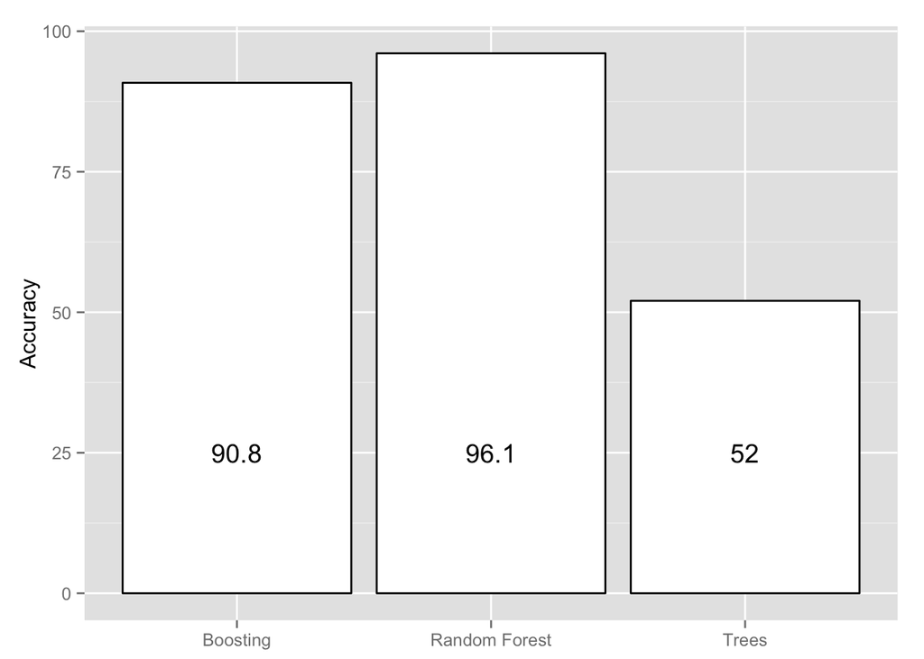

```r
# make histogram
hist.dt <- data.frame(Type = c("Boosting", "Random Forest", "Trees"),
                      Accuracy = c(res.bo, res.rf, res.t))
ggplot(hist.dt, aes(x = Type, weight = Accuracy)) +
    geom_bar(fill = "white", colour = "black")+
    geom_text(aes(y = 25, label = round(Accuracy, 1)))+
    labs(x = NULL, y = "Accuracy")
```

Final prediction:

```r
# predict test set with rendom forest
prediction <- predict(fit.rf, newdata = test)
```